# Design Declaration

Punish or Reconcile? Target Framing, Performance Cues, and Authoritarian Legitimation through Repression

Authors

Daniel Kuhlen

Giovanna Lapresa

Jorge Zavala

Published

March 18, 2026

# Theory

This experiment examines how citizens update their support for repressive government policies based on three informational dimensions: the nature of the justice policy (punitive vs. restorative), the framing of the targeted group (as a threat or not), and performance information about the policy (positive, negative, or absent).

We build on Lachapelle (2022)’s triadic model of repression, which theorizes that bystander citizens evaluate repressive policies through a legitimacy lens, and extend it with a performance dimension following Przeworski (2023).

## Mechanism: Implicit Performance Beliefs

Our central hypothesis is that citizens support punitive justice policies partly because they *implicitly assume* these policies are more effective—especially when the targeted group is framed as a threat. The performance dimension in our design allows us to test this mechanism.

Following Acharya, Blackwell, and Sen (2018), we treat performance information as a **manipulated mediator** for the justice frame effect. When no performance information is provided (the “natural-mediator” condition), respondents rely on their prior beliefs about policy effectiveness—which we hypothesize are biased toward assuming punitive policies work better. When performance information *is* provided (the “manipulated-mediator” condition), these implicit beliefs are overridden by the experimental cue, and the justice frame effect should change.

The **eliminated effect** (Acharya, Blackwell, and Sen 2018)—the difference between the justice frame effect with and without performance information—captures how much of the punitive justice premium is explained by implicit performance beliefs (through either indirect effects or causal interactions). A large eliminated effect would indicate that performance assumptions are a key mechanism driving support for punitive repression.

# Design

We implement a **2 x 2 x 3 conjoint-style vignette experiment** with repeated measures. Each respondent reads a series of short vignettes describing a government policy and is asked to rate their support for the policy on a 0–10 scale after each one.

## Factors

The three experimental factors and their levels are:

| Factor | Levels | Description |
| --- | --- | --- |
| **Justice Policy** | Punitive, Restorative | Whether the policy is framed as punitive or restorative |
| **Threat Framing** | Threat, No Threat | Whether the targeted group is described as a threat |
| **Performance Information** | None, Positive, Negative | Whether and what kind of policy performance information is provided |

This factorial crossing produces **12 unique vignette types** (2 x 2 x 3 = 12).

## Within-Subjects Design

Each respondent is randomly assigned to see **K = 5** vignette scenarios. After reading each vignette, the respondent answers the same outcome battery (support for repressive policy on a 0–10 scale). This within-subjects repeated-measures design dramatically increases the effective analytical sample: with N respondents, we observe N x K = N x 5 respondent-vignette observations.

## Randomization Strategy

Following Hainmueller, Hopkins, and Yamamoto (2014), we use **full independent randomization** of attribute levels for each task:

1. For each of the K = 5 tasks per respondent, the three attribute levels are drawn independently and uniformly from their respective levels
2. This means a respondent may see the same vignette type more than once, which preserves the independence assumption required for nonparametric identification of Average Marginal Component Effects (AMCEs, Hainmueller, Hopkins, and Yamamoto 2014)
3. Vignette task order is randomized across respondents

Per Humphreys (2026), we are explicit that our estimands are **effects of information** (the vignette content) on stated policy support, not effects on underlying beliefs or latent preferences. We also note the risk of cross-attribute belief updating: seeing a “punitive” justice frame may cause respondents to infer threat, which we address through the fully randomized design that breaks any structural correlation between attributes.

## Causal Mechanisms via Manipulated Mediator

Following Acharya, Blackwell, and Sen (2018), the 2 x 2 x 3 design can be read as a conjoint experiment with an embedded manipulated-mediator structure:

- **Natural-mediator arm** (performance = “none”): Only the justice and threat frames are varied. Respondents rely on their *implicit beliefs* about policy effectiveness. In this arm, we estimate the **total effect** of the justice frame, which bundles together direct preferences and any indirect effect flowing through assumed effectiveness.
- **Manipulated-mediator arms** (performance = “positive” or “negative”): Performance information is provided, fixing the respondent’s information about policy effectiveness at a particular value. In these arms, we estimate the **controlled direct effect** (ACDE) of the justice frame—the part of the effect that persists even when effectiveness beliefs are experimentally overridden.

The **eliminated effect** is the difference: $\Delta = \text{ATE}_{\text{justice}} - \text{ACDE}_{\text{justice}}$. A positive eliminated effect indicates that implicit performance beliefs explain part of the punitive justice premium, either through mediation (punitive → assumed effective → support) or interaction (the justice effect depends on effectiveness context). Following Acharya, Blackwell, and Sen (2018), this design avoids the strong sequential ignorability assumption of traditional mediation analysis by *randomizing* the mediator rather than merely observing it.

## Design Declaration

The **model** assumes additive main effects for the three factors on support for repressive policy (0–10 scale), plus an interaction between the justice frame and performance information provision—reflecting the hypothesis that providing performance information changes the justice frame effect. The data-generating process includes a respondent-level random intercept and task-level noise, producing within-respondent correlation (ICC $\approx$ 0.8) consistent with repeated attitudinal measures. Baseline parameters (population mean $\mu$ = 4, standard deviation $\sigma$ = 2) are placeholders.

The **inquiry** consists of four AMCEs, plus the eliminated effect following Acharya, Blackwell, and Sen (2018): the difference between the justice frame AMCE in the natural-mediator arm (no performance info) and in the manipulated-mediator arms (performance info provided). This captures how much of the punitive justice premium is explained by implicit performance beliefs.

The **data strategy** implements full independent randomization of attribute levels for each respondent-task observation, following the conjoint design described above.

The **answer strategy** uses OLS with CR2 cluster-robust standard errors at the respondent level, following Hainmueller, Hopkins, and Yamamoto (2014)’s recommendation for conjoint designs with multiple tasks per respondent. The eliminated effect is estimated via a justice $\times$ performance-info interaction term.

```r
# set seed
set.seed(030)

# wrap the design in a function for parameter variation
declare_conjoint_design <- function(

  # number of survey respondents
  N              = 2000,
  # number of vignette tasks per respondent
  K              = 5,
  # baseline mean support for repressive policy (0-10 scale)
  mu             = 4,
  # population standard deviation (respondent-level)
  sigma          = 2,
  # AMCE of punitive (vs. restorative) justice frame
  tau_justice    = 0.8,
  # AMCE of threat (vs. no threat) framing
  tau_threat     = 1.2,
  # AMCE of positive performance info (vs. no info) - expected to reduce support
  tau_perf_pos   = -0.5,
  # AMCE of negative performance info (vs. no info) - expected to increase support
  tau_perf_neg   = 0.5,
  # interaction: how much the justice effect changes when performance info is provided
  # negative = providing performance info reduces the punitive premium (as hypothesized)
  # following Acharya, Blackwell & Sen (2018): eliminated effect = -tau_interact
  tau_interact   = -0.4
) {

  # total number of respondent-task observations
  N_obs <- N * K

  # m: model ----------------------------------------------------------------
  # each row is a respondent-task pair

  model <- declare_model(
    N = N_obs,
    respondent_id = rep(1:(N/K), each = K),
    task = rep(1:K, times = N/K),
    # respondent-level random intercept (constant within respondent)
    u_i = rep(rnorm(N/K, 0, sigma), each = K),
    # task-level noise (varies across tasks within respondent)
    e_ij = rnorm(N, 0, sigma * 0.5)
  )

  # d: data strategy --------------------------------------------------------
  # fully randomize each attribute independently for each respondent-task
  # following Hainmueller, Hopkins & Yamamoto (2014)

  assign_justice <- declare_assignment(
    Z_justice = complete_ra(N = N_obs, prob = 0.5)
  )

  assign_threat <- declare_assignment(
    Z_threat = complete_ra(N = N_obs, prob = 0.5)
  )

  # performance has 3 levels: "none" (baseline), "positive", "negative"
  assign_performance <- declare_assignment(
    Z_performance = complete_ra(
      N = N_obs,
      conditions = c("none", "positive", "negative")
    )
  )

  # measurement: construct outcome with explicit dummy variables
  # includes justice x performance-info interaction (Acharya et al. 2018)
  measure_Y <- declare_measurement(
    perf_positive = as.numeric(Z_performance == "positive"),
    perf_negative = as.numeric(Z_performance == "negative"),
    has_perf_info = as.numeric(Z_performance != "none"),
    Y = pmin(10, pmax(0,
      mu +
      tau_justice   * Z_justice +
      tau_threat    * Z_threat +
      tau_perf_pos  * perf_positive +
      tau_perf_neg  * perf_negative +
      tau_interact  * Z_justice * has_perf_info +
      u_i + e_ij
    ))
  )

  # i: inquiry --------------------------------------------------------------
  # AMCEs: the average effect of switching each attribute from baseline

  inquiry_justice <- declare_inquiry(
    AMCE_Justice = tau_justice,
    label = "AMCE: Punitive vs. Restorative"
  )

  inquiry_threat <- declare_inquiry(
    AMCE_Threat = tau_threat,
    label = "AMCE: Threat vs. No Threat"
  )

  inquiry_perf_pos <- declare_inquiry(
    AMCE_Perf_Positive = tau_perf_pos,
    label = "AMCE: Positive Performance vs. None"
  )

  inquiry_perf_neg <- declare_inquiry(
    AMCE_Perf_Negative = tau_perf_neg,
    label = "AMCE: Negative Performance vs. None"
  )

  # justice x performance-info interaction (Acharya et al. 2018)
  # this is the change in the justice effect when performance info is provided
  # negative value = performance info reduces the punitive premium
  # the eliminated effect is the negative of this: -tau_interact > 0
  inquiry_interaction <- declare_inquiry(
    Justice_x_PerfInfo = tau_interact,
    label = "Justice x Perf Info Interaction"
  )

  # a: answer strategy -------------------------------------------------------
  # OLS with cluster-robust SEs at respondent level

  # (1) main effects model for AMCEs
  estimator_amce <- declare_estimator(
    Y ~ Z_justice + Z_threat + perf_positive + perf_negative,
    .method = lm_robust,
    clusters = respondent_id,
    se_type = "CR2",
    term = c("Z_justice", "Z_threat", "perf_positive", "perf_negative"),
    inquiry = c("AMCE_Justice", "AMCE_Threat",
                "AMCE_Perf_Positive", "AMCE_Perf_Negative"),
    label = "AMCEs (main effects)"
  )

  # (2) interaction model for eliminated effect (Acharya et al. 2018)
  # the coefficient on Z_justice:has_perf_info estimates how the justice effect
  # changes when performance info is provided; eliminated effect = -1 * this
  estimator_mechanism <- declare_estimator(
    Y ~ Z_justice * has_perf_info + Z_threat + perf_positive + perf_negative,
    .method = lm_robust,
    clusters = respondent_id,
    se_type = "CR2",
    term = "Z_justice:has_perf_info",
    inquiry = "Justice_x_PerfInfo",
    label = "Justice x Perf Info (interaction)"
  )

  # chain MIDA components
  model +
    assign_justice + assign_threat + assign_performance +
    measure_Y +
    inquiry_justice + inquiry_threat + inquiry_perf_pos + inquiry_perf_neg +
    inquiry_interaction +
    estimator_amce + estimator_mechanism
}

# instantiate with defaults
base_design <- declare_conjoint_design()

# run simulated experiments and compute diagnosands
diagnosis <- diagnose_design(base_design, sims = 500)
```

[output not shown]

```r
# display results
diagnosis$diagnosands_df |>
  select(
    Estimand    = inquiry,
    `True AMCE` = mean_estimand,
    Estimate    = mean_estimate,
    Bias        = bias,
    SD          = sd_estimate,
    RMSE        = rmse,
    Power       = power,
    Coverage    = coverage
  ) |>
  mutate(across(where(is.numeric), \(x) round(x, 3))) |>
  knitr::kable(
    caption = "Design diagnosis (500 simulations, N = 2,000, K = 5 tasks per respondent)",
    align   = c("l", rep("r", 7))
  )
```

Design diagnosis (500 simulations, N = 2,000, K = 5 tasks per respondent)

| Estimand | True AMCE | Estimate | Bias | SD | RMSE | Power | Coverage |
| --- | --- | --- | --- | --- | --- | --- | --- |
| AMCE_Justice | 0.8 | 0.516 | -0.284 | 0.043 | 0.287 | 1 | 0.000 |
| AMCE_Perf_Negative | 0.5 | 0.296 | -0.204 | 0.051 | 0.210 | 1 | 0.020 |
| AMCE_Perf_Positive | -0.5 | -0.671 | -0.171 | 0.052 | 0.179 | 1 | 0.102 |
| AMCE_Threat | 1.2 | 1.162 | -0.038 | 0.042 | 0.056 | 1 | 0.856 |
| Justice_x_PerfInfo | -0.4 | -0.384 | 0.016 | 0.092 | 0.093 | NA | NA |

The **Justice x Perf Info interaction** row captures the eliminated effect logic from Acharya, Blackwell, and Sen (2018). A negative coefficient means that providing performance information *reduces* the punitive justice premium—evidence that implicit performance beliefs are part of the causal mechanism. The eliminated effect (ATE$_{\text{justice}}$ $-$ ACDE$_{\text{justice}}$) is the negative of this coefficient. In the simulation, the true interaction is $\tau_{\text{interact}}$ = -0.4, meaning that 0.4 scale points of the punitive premium (out of 0.8 total) are explained by implicit performance assumptions.

## Power by Sample Size

```r
# vary sample size
n_vals <- c(500, 750, 1000, 1500, 2000, 2500)

designs_by_n <- setNames(
  lapply(n_vals, function(n) declare_conjoint_design(N = n)),
  paste0("N=", n_vals)
)

diagnoses_by_n <- diagnose_design(designs_by_n, sims = 500)
```

[output not shown]

[output not shown]

[output not shown]

[output not shown]

[output not shown]

[output not shown]

[output not shown]

[output not shown]

[output not shown]

[output not shown]

[output not shown]

[output not shown]

[output not shown]

[output not shown]

[output not shown]

[output not shown]

[output not shown]

[output not shown]

[output not shown]

[output not shown]

[output not shown]

[output not shown]

[output not shown]

[output not shown]

[output not shown]

[output not shown]

[output not shown]

[output not shown]

[output not shown]

[output not shown]

[output not shown]

[output not shown]

[output not shown]

[output not shown]

[output not shown]

[output not shown]

[output not shown]

[output not shown]

[output not shown]

[output not shown]

[output not shown]

[output not shown]

[output not shown]

[output not shown]

[output not shown]

[output not shown]

[output not shown]

[output not shown]

[output not shown]

[output not shown]

[output not shown]

[output not shown]

[output not shown]

[output not shown]

[output not shown]

[output not shown]

[output not shown]

[output cut: 68 more lines]

[output not shown]

[output not shown]

[output not shown]

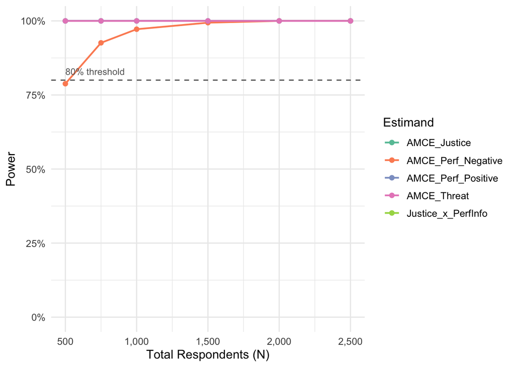

Figure 1: Statistical power for each AMCE as a function of total sample size (N). K = 5 tasks per respondent. Dashed line marks the 80% power threshold.

```r
n_lookup <- tibble(
  design = paste0("N=", n_vals),
  N = n_vals
)

diagnoses_by_n$diagnosands_df |>
  left_join(n_lookup, by = "design") |>
  ggplot(aes(x = N, y = power, color = inquiry, group = inquiry)) +
  geom_line(linewidth = 0.8) +
  geom_point(size = 1.8) +
  geom_hline(yintercept = 0.80, linetype = "dashed", color = "gray40") +
  annotate("text", x = 500, y = 0.83, label = "80% threshold",
           hjust = 0, size = 3.2, color = "gray40") +
  scale_color_brewer(palette = "Set2", name = "Estimand") +
  scale_y_continuous(limits = c(0, 1), labels = percent_format(accuracy = 1)) +
  scale_x_continuous(labels = comma) +
  labs(x = "Total Respondents (N)", y = "Power") +
  theme_minimal(base_size = 12) +
  theme(legend.position = "right")
```

## References

Acharya, Avidit, Matthew Blackwell, and Maya Sen. 2018. “Analyzing Causal Mechanisms in Survey Experiments.” *Political Analysis* 26 (4): 357–78. https://doi.org/10.1017/pan.2018.19.

Bansak, Kirk, Jens Hainmueller, Daniel J. Hopkins, and Teppei Yamamoto. 2021. “Beyond the Breaking Point? Survey Satisficing in Conjoint Experiments.” *Political Science Research and Methods* 9 (1): 53–71. https://doi.org/10.1017/psrm.2019.13.

Hainmueller, Jens, Daniel J. Hopkins, and Teppei Yamamoto. 2014. “Causal Inference in Conjoint Analysis: Understanding Multidimensional Choices via Stated Preference Experiments.” *Political Analysis* 22 (1): 1–30. https://doi.org/10.1093/pan/mpt024.

Humphreys, Macartan. 2026. “Three Risks in the Design and Interpretation of Conjoint Experiments.”

Lachapelle, Jean. 2022. “Repression Reconsidered: Bystander Effects and Legitimation in Authoritarian Regimes.” *Comparative Politics* 54 (4): 695–716. https://doi.org/10.5129/001041522X16317396828722.

Przeworski, Adam. 2023. “Formal Models of Authoritarian Regimes: A Critique.” *Perspectives on Politics* 21 (3): 979–88. https://doi.org/10.1017/S1537592722002067.